# Vignette Title

Vignette Author

2019-01-18

- Never uses retina figures
- Has a smaller default figure size
- Uses a custom CSS stylesheet instead of the default Twitter Bootstrap style

## Styles

```
output:
  rmarkdown::html_vignette:
    css: mystyles.css
```

## Figures

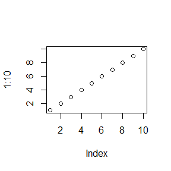

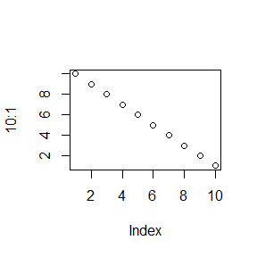

```r
plot(1:10)
plot(10:1)
```

You can enable figure captions by `fig_caption: yes` in YAML:

```
output:
  rmarkdown::html_vignette:
    fig_caption: yes
```

Then you can use the chunk option `fig.cap = "Your figure caption."` in **knitr**.

## More Examples

You can write math expressions, e.g. $Y = X\beta + \epsilon$, footnotes[^1], and tables, e.g. using `knitr::kable()`.

|  | mpg | cyl | disp | hp | drat | wt | qsec | vs | am | gear | carb |
| --- | --- | --- | --- | --- | --- | --- | --- | --- | --- | --- | --- |
| Mazda RX4 | 21.0 | 6 | 160.0 | 110 | 3.90 | 2.620 | 16.46 | 0 | 1 | 4 | 4 |
| Mazda RX4 Wag | 21.0 | 6 | 160.0 | 110 | 3.90 | 2.875 | 17.02 | 0 | 1 | 4 | 4 |
| Datsun 710 | 22.8 | 4 | 108.0 | 93 | 3.85 | 2.320 | 18.61 | 1 | 1 | 4 | 1 |
| Hornet 4 Drive | 21.4 | 6 | 258.0 | 110 | 3.08 | 3.215 | 19.44 | 1 | 0 | 3 | 1 |
| Hornet Sportabout | 18.7 | 8 | 360.0 | 175 | 3.15 | 3.440 | 17.02 | 0 | 0 | 3 | 2 |
| Valiant | 18.1 | 6 | 225.0 | 105 | 2.76 | 3.460 | 20.22 | 1 | 0 | 3 | 1 |
| Duster 360 | 14.3 | 8 | 360.0 | 245 | 3.21 | 3.570 | 15.84 | 0 | 0 | 3 | 4 |
| Merc 240D | 24.4 | 4 | 146.7 | 62 | 3.69 | 3.190 | 20.00 | 1 | 0 | 4 | 2 |
| Merc 230 | 22.8 | 4 | 140.8 | 95 | 3.92 | 3.150 | 22.90 | 1 | 0 | 4 | 2 |
| Merc 280 | 19.2 | 6 | 167.6 | 123 | 3.92 | 3.440 | 18.30 | 1 | 0 | 4 | 4 |

Also a quote using `>`:

> “He who gives up [code] safety for [code] speed deserves neither.” ([via](https://twitter.com/hadleywickham/status/504368538874703872))

## Overview

Homework1 ##example1

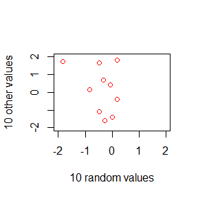

```r
x<-rnorm(10)
y<-rnorm(10)
plot(x,y,xlab="10 random values",ylab="10 other values",xlim=c(-2,2),ylim=c(-2,2),col="red")
```

```r
square <- function(x)  x^2
square(1:5)
```

```
#> [1]  1  4  9 16 25
```

```r
is.min <- function(x)      x == min(x)

a = runif(10)
is.min(a)
```

```
#>  [1] FALSE  TRUE FALSE FALSE FALSE FALSE FALSE FALSE FALSE FALSE
```

```r
a[is.min(a)]
```

```
#> [1] 0.1790606
```

```r
which(is.min(a))
```

```
#> [1] 2
```

## example3

```r
x <- c("m", "f", "u", "f", "f", "m", "m")
lookup <- c(m = "Male", f = "Female", u = NA)
lookup[x]
```

```
#>        m        f        u        f        f        m        m
#>   "Male" "Female"       NA "Female" "Female"   "Male"   "Male"
```

Homework2 exercise3.5

Question ： Using inverse transform method to generate a random sample.Then construct afrequeny table and compare with the theory.

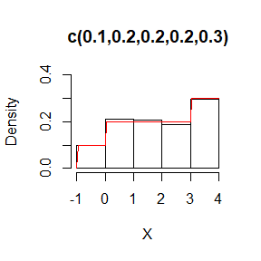

```r
U=runif(1000)#随机数
X = 0*I(U<=0.1) + 1*I( U>0.1 & U<=0.3) + 2*I( U>0.3 & U<=0.5)+3*I( U>0.5 & U<=0.7)+4*I( U>0.7 & U<=1)#逆函数
hist(X, breaks=-1:4,ylim=c(0,0.4) ,main = "c(0.1,0.2,0.2,0.2,0.3)",freq=FALSE)#图
fy<-function(x)  0.1*I(x<=0&x>-1)+0.2*I(x>0&x<=3)+0.3*I(x<=4&x>3) #理论函数
curve(fy,from=-1,to=4,add=T,col="red")#理论图
```

```r
table(X)#频率表
```

```
#> X
#>   0   1   2   3   4
#>  97 212 208 187 296
```

exercise3.7

Question： Using the acceptance-rejection method to generate random sample of Beta(3,2)

```r
f1<-function(x)
{
t<-x^2*(1-x)/beta(3,2)
t
}#cdf of beta(3,2)
rej1<-function(n)
{
   xvec<-runif(n,0,1);
   u<-runif(n,0,1);
   zvec<-xvec[u<(f1(xvec)/2)]
   zvec
}#acceptance-rejection method
NROW(rej1(5000))#efficient
```

```
#> [1] 2458
```

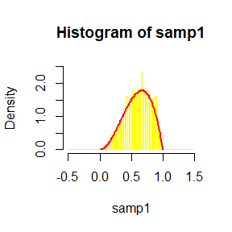

```r
samp1<-rej1(5000)[1:1000]#getting 1000 random number
hist(samp1,freq=FALSE,breaks=seq(-0.5,1.5,0.02),ylim=c(0,2.5),border="yellow")
curve(f1,from=0,to=1,add=T,col="red",lwd=2) #plot
```

exercise3.12

Question：simulate a continous Exponential-Gamma mixture

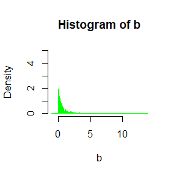

```r
a<-rgamma(1000,4,2)
b=rep(0,1000)
for(i in 1:1000)
{
  b[i]<-rexp(1,a[i])
}
hist(b,freq=FALSE,breaks=seq(min(b)-1,max(b)+1,0.05),ylim=c(0,5),border="green")
```

```r
n=500
m=1000
v<-2*(1:n)-n-1

t<-numeric(m)
for(i in 1:m)
{
 x<-sort(rlnorm(n))
 meanx<-mean(x)
 t[i]<-(1/(n^2*exp(0.5)))*as.numeric(v%*%x)
}
```

mean

```r
mean(t)
```

```
#> [1] 0.5188549
```

median

```r
median(t)
```

```
#> [1] 0.516295
```

```r
quantile(t, probs = seq(0.1,0.9,0.1))
```

```
#>       10%       20%       30%       40%       50%       60%       70%
#> 0.4624419 0.4794767 0.4929714 0.5064108 0.5162950 0.5270807 0.5383981
#>       80%       90%
#> 0.5548248 0.5792189
```

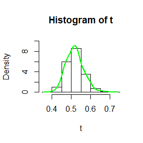

```r
hist(t,prob=TRUE,ylim = c(0,10))
lines(density(t),col="green",lwd=2)
```

```r
for(i in 1:m)
{
 x<-sort(runif(n))
 meanx<-mean(x)
 t[i]<-(1/(n^2*exp(meanx)))*as.numeric(v%*%x)
}
```

```r
mean(t)
```

```
#> [1] 0.1008395
```

```r
median(t)
```

```
#> [1] 0.1008685
```

```r
quantile(t, probs = seq(0.1,0.9,0.1))
```

```
#>        10%        20%        30%        40%        50%        60%
#> 0.09749304 0.09868139 0.09953335 0.10019816 0.10086854 0.10151450
#>        70%        80%        90%
#> 0.10217769 0.10301496 0.10405838
```

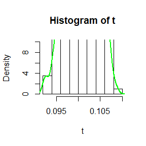

```r
hist(t,prob=TRUE,ylim = c(0,10))
lines(density(t),col="green",lwd=2)
```

6.10 Construct an approxiamate 95% cinfidence interval for the Gini ratio γ=E[G]γ=E[G] if X is lognormal with unknown parameters.Assess the coverage rate of the estimation procedure with a Monte Carlo experiment.

Analysis: Firstly,generating sample of rlnorm(n,a,b).Both a and b is random. Then calculate Giniof the sample and confidence interval ,finally getting the coverage rate.

```r
set.seed(1234)
n<-1000              #generate 1000 random numbers
m<-100               #generate 100 gini ratio every times
k=100                #repeat 100 times
Glnorm<-1:m
gamma.hat<-sdgamma.hat<-cpgamma<-1:k
v<-2*(1:n)-n-1

for(j in 1:k)
{
for(i in 1:m)
{
  a=runif(1)#random mean
  b=runif(1)#random sd

  x<-sort(rlnorm(n,a,b))
  meanx<-mean(x)
  Glnorm[i]<-(1/(n^2*exp(meanx)))*as.numeric(v%*%x)
}
  gamma.hat[j]<-mean(Glnorm)
  sdgamma.hat[j]<-sd(Glnorm)
  cpgamma[j]<-(1/m)*sum(I(gamma.hat[j]-qt(0.975,m-2)*sdgamma.hat[j]<Glnorm & Glnorm<gamma.hat[j]+qt(0.975,m-2)*sdgamma.hat[j]))
}
```

the coverage rate

```r
mean(cpgamma)
```

```
#> [1] 0.9726
```

6.B Tests for association based in Pearson product moment correlationρρ,Spearman’s rank correlation coefficient ρsρs,or Kendall’s coefficient ττ,are implemented in cor.test.Show that the nonparametric tests based onρρ or ττ are less powerful tha the corelation test when the sampled distribution is bivariate noraml.Find an example of an alternative(a bivariate distribution (X,Y) such that X and Y are dependent )such that at least one of the nonparametric tests have better empirical power than the correlation test against this alternative.

Analysis: we use three methods to test the correlation and situmulate the empirically power.

```r
#(1)
alpha=0.1
m<-2500
n=100
test1<-test2<-test3<-numeric(m)
#estimate
for(j in 1:m)
{
u1=runif(1)
sd1=runif(1,0,5)
u2=runif(2)
sd2=runif(1,0,2)
x<-rnorm(n,u1,sd1)
y<-rnorm(n,u2,sd2)
test1[j]<-as.integer(cor.test(x,y,method="pearson")$p.value<=alpha)#pearson
test2[j]<-as.integer(cor.test(x,y,method="spearman")$p.value<=alpha)#spearman
test3[j]<-as.integer(cor.test(x,y,method="kendall")$p.value<=alpha)#kendall
}
```

```r
mean(test1)
```

```
#> [1] 0.1004
```

```r
mean(test2)
```

```
#> [1] 0.0984
```

```r
mean(test3)
```

```
#> [1] 0.0972
```

we select the uniform distribution #(2)

```r
test1<-test2<-test3<-numeric(m)
m=1000
n=100
for(j in 1:m)
{
  x<-y<-numeric(n)
  for(i in 1:n)
  {
    x[i]<-runif(1,-1,1)
    t=x[i]
    y[i]<-runif(1,-sqrt(1-t^2),sqrt(1-t^2))
  }
  test1[j]<-as.integer(cor.test(x,y,method="pearson")$p.value<=alpha)#pearson
  test2[j]<-as.integer(cor.test(x,y,method="spearman")$p.value<=alpha)#spearman
  test3[j]<-as.integer(cor.test(x,y,method="kendall")$p.value<=alpha)#kendall
}
```

```r
mean(test1)
```

```
#> [1] 0.0148
```

```r
mean(test2)
```

```
#> [1] 0.02
```

```r
mean(test3)
```

```
#> [1] 0.0104
```

Homework4 ## Question 1 Compute a jackknife estimate of the bias and the standard error of the correlation statistic in Example 7.2.

## Answer 1

```r
library(bootstrap)
LSAT=law$LSAT
GPA=law$GPA
n = length( LSAT ) #numbeer of data
cor_jack = numeric( n )
cor_hat = cor( LSAT,GPA ) #corelation of LSAT  and GPA
```

```r
for (i in 1:n) { cor_jack[i] = cor( LSAT[-i],GPA[-i] ) }
bias_jack = (n-1)*( mean(cor_jack) - cor_hat )
cor_bar = mean(cor_jack) # mean of statistic generated from jackknife
se_jack = sqrt( (n-1)*mean( (cor_jack-cor_bar)^2 ) )

print(sprintf('estimate of the bias  of the correlation statistic is: %f',bias_jack ))
```

```
#> [1] "estimate of the bias  of the correlation statistic is: -0.006474"
```

```r
print(sprintf('estimate of the standard error of the correlation statistic is: %f',se_jack ))
```

```
#> [1] "estimate of the standard error of the correlation statistic is: 0.142519"
```

## Question 2

Refer to Exercise 7.4. Compute 95% bootstrap confidence intervals for the mean time between failures $\frac{1}{\lambda}$ by the standard normal, basic, percentile, and BCa methods. Compare the intervals and explain why they may differ.

## Answer 2

```r
library(boot)
attach(aircondit)
x = hours
B = 5000
set.seed(1)
```

```r
gaptime_hat = mean(x) #MLE of 1/lambda
#bootstrap estimate of 1/lambda
frac_1_lambda_boot = boot(data=aircondit,statistic=function(x,i){mean(x[i,])}, R=B )

frac_1_lambda_boot
```

```
#>
#> ORDINARY NONPARAMETRIC BOOTSTRAP
#>
#>
#> Call:
#> boot(data = aircondit, statistic = function(x, i) {
#>     mean(x[i, ])
#> }, R = B)
#>
#>
#> Bootstrap Statistics :
#>     original  bias    std. error
#> t1* 108.0833  0.2438    37.77646
```

We see the MLE is 1/lambda = 108.0833, with estimated std. error = 37.77646, bias = 0.2438.

Next we try to calculate the bootstrap intervals by the standard normal, basic, percentile, and BCa methods.

```r
einf_jack = empinf(frac_1_lambda_boot, type='jack')
boot.ci( frac_1_lambda_boot, type=c('norm','basic','perc','bca'), L=einf_jack )
```

```
#> BOOTSTRAP CONFIDENCE INTERVAL CALCULATIONS
#> Based on 5000 bootstrap replicates
#>
#> CALL :
#> boot.ci(boot.out = frac_1_lambda_boot, type = c("norm", "basic",
#>     "perc", "bca"), L = einf_jack)
#>
#> Intervals :
#> Level      Normal              Basic
#> 95%   ( 33.8, 181.9 )   ( 25.8, 170.5 )
#>
#> Level     Percentile            BCa
#> 95%   ( 45.7, 190.3 )   ( 54.9, 222.2 )
#> Calculations and Intervals on Original Scale
```

We see the intervals are quite different. A primary reason is that the bootstrap distribution is still skewed, affecting the simpler methods and their appeal to the Central Limit Theorem. For example

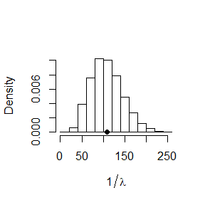

```r
hist(frac_1_lambda_boot$t, main='', xlab=expression(1/lambda), prob=T)
points(frac_1_lambda_boot$t0, 0, pch = 19)
```

The BCa interval incorporates an acceleration adjustment for skew, and may be preferred here.

## Question 3

Refer to Exercise 7.7. Obtain the jackknife estimates of bias and standard error of $\hat{\theta}$.

## Answer 3

```r
library(bootstrap)
attach( scor )
n = length( scor[,1] )
x = as.matrix(scor)
theta_jack = numeric( n )
```

```r
lambda_hat = eigen(cov(scor))$values
theta_hat = lambda_hat[1]/sum(lambda_hat) #compute the mean of theta from sample
#according to the formala, we write a function to calculate the theta.
theta = function(x){
 eigen(cov(x))$values[1]/sum(eigen(cov(x))$values)
}

for (i in 1:n) { theta_jack[i] = theta( x[-i,] ) }

theta_bar = mean(theta_jack)
bias_jack = (n-1)*( mean(theta_jack) - theta_hat )
se_jack = sqrt( (n-1)*mean( (theta_jack-theta_bar)^2 ) )

print(sprintf('the jackknife estimates of bias of hat of theta is : %f', bias_jack))
```

```
#> [1] "the jackknife estimates of bias of hat of theta is : 0.001069"
```

```r
print(sprintf('the jackknife estimates of standard error of hat of theta is : %f', se_jack))
```

```
#> [1] "the jackknife estimates of standard error of hat of theta is : 0.049552"
```

```r
detach(scor)
```

## Question 4

In Example 7.18, leave-one-out (n-fold) cross validation was used to select the best fitting model. Use leave-two-out cross validation to compare the models.